# More Visualization

# Overview

## ggplot2

ggplot2 developed by Hadley Wickham, based on the “grammar of graphics”. Particularly well suited (IMHO) for multi-dimensional, multivariate analysis.

Requires 3 things:

1. Data
2. Mapping
3. Geometric layers

Supports 2 more things:

1. Scales
2. Non-data elements

## Data

```r
library(raw)
data(RegionExperience)
library(tidyverse)

basePlot <- ggplot(RegionExperience)
class(basePlot)
```

```
## [1] "gg"     "ggplot"
```

## Data w/o mapping = boring

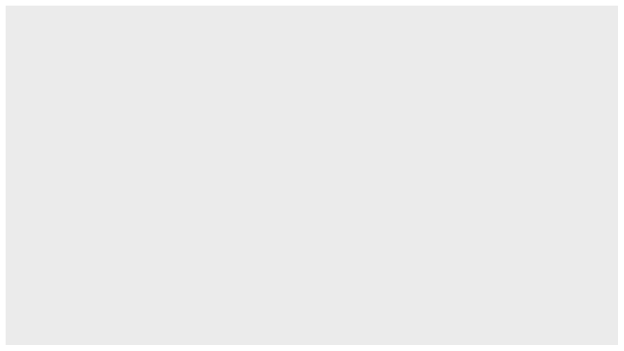

```r
basePlot
```

## Aesthetics

Aesthetics are anything visible on the plot. When an aesthetic is “mapped”, it means that the data will define how the aesthetic appears. We’ll map our aesthetics with the `aes` function.

```r
basePlot <- basePlot + aes(x = PolicyYear, y = NumClaims, color=Region)
```

## Data + mapping = still boring

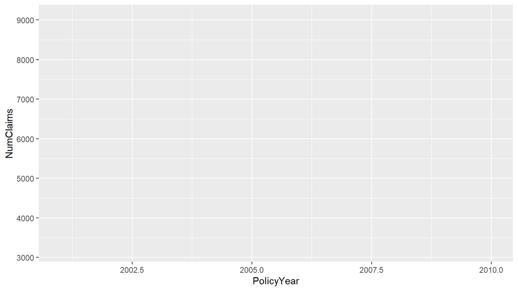

```r
basePlot
```

## Adding layers

The `geom_*` functions clarify how the data should be rendered.

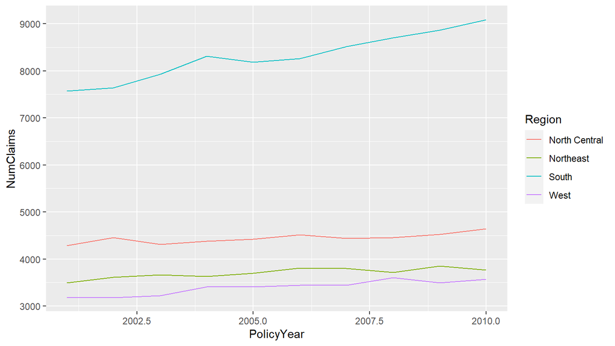

```r
p <- basePlot + geom_line()
p
```

## Adding layers

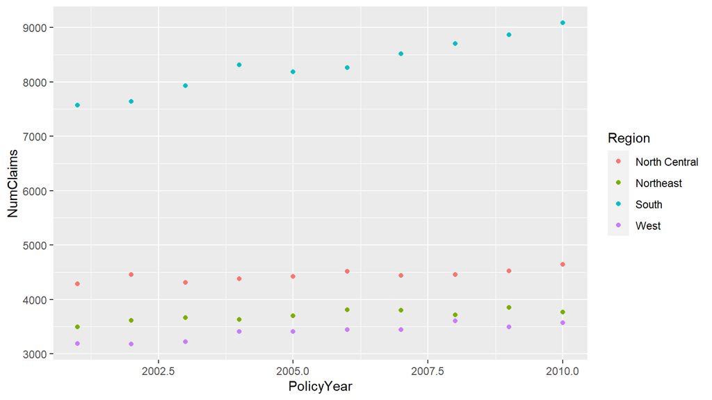

```r
p <- basePlot + geom_point()
p
```

## Nothing wrong with adding two layers

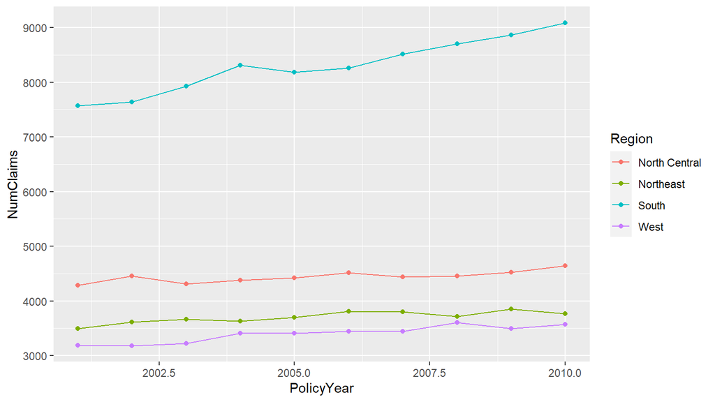

```r
p <- basePlot + geom_point() + geom_line()
p
```

## One step

Typically we don’t do this in steps.

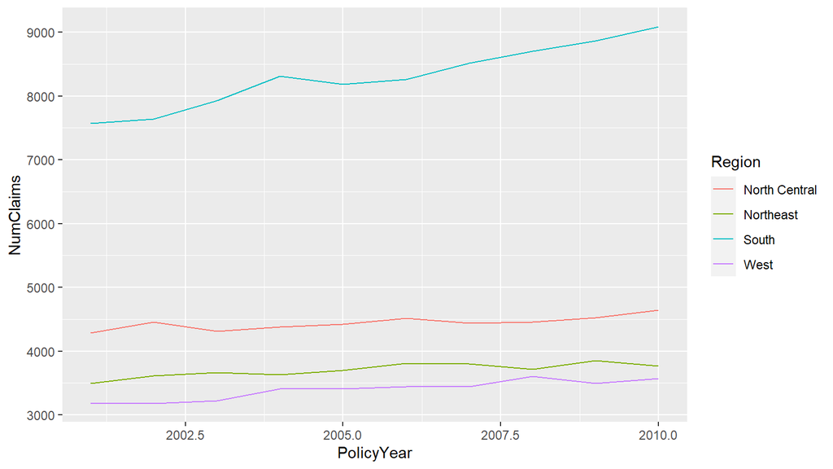

```r
p <- RegionExperience %>%
  ggplot(aes(x = PolicyYear, y = NumClaims, color = Region)) +
  geom_line()

p
```

## What’s wrong with this code?

```r
RegionExperience %>%
  ggplot(aes(x = PolicyYear, y = NumClaims)) +
  geom_line(color = Region)
```

```
## Error in layer(data = data, mapping = mapping, stat = stat, geom = GeomLine, : object 'Region' not found
```

## Layers have loads of parameters

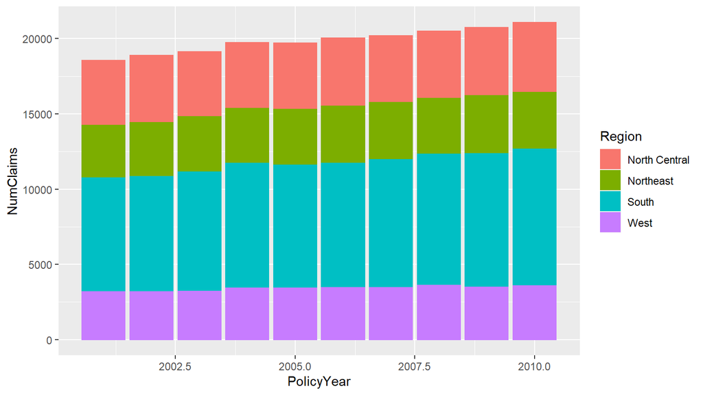

```r
p <- basePlot + geom_bar(stat="identity", aes(fill = Region))
p
```

## Mmm, parameters

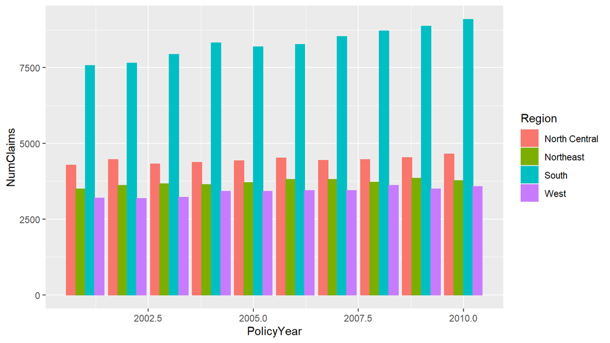

```r
p <- basePlot + geom_bar(stat="identity", position="dodge", aes(fill=Region))
p
```

## Layer parameters

How do I know which parameters do what? Help, google and stack overflow are your friends.

# More features

## Facets

```r
data(StateExperience)
p <- StateExperience %>%
  ggplot(aes(x = PolicyYear, y = NumClaims, color = State)) +
  geom_point() +
  facet_wrap(~ Region) +
  theme(legend.position = "none")
```

## Facets

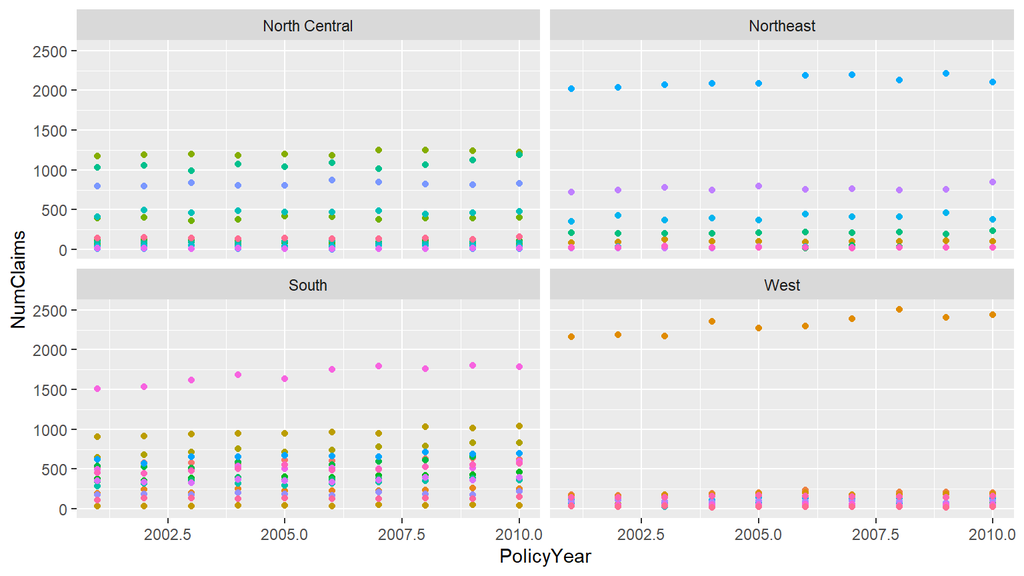

## Statistical smoothers

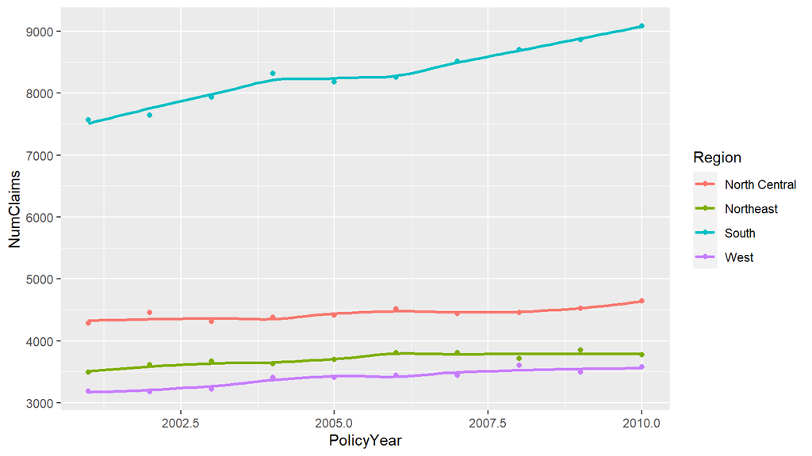

```r
p <- RegionExperience %>%
  ggplot(aes(x = PolicyYear, y = NumClaims, group=Region, color=Region)) +
  geom_point()
p + geom_smooth(se = FALSE)
```

## Statistical transforms

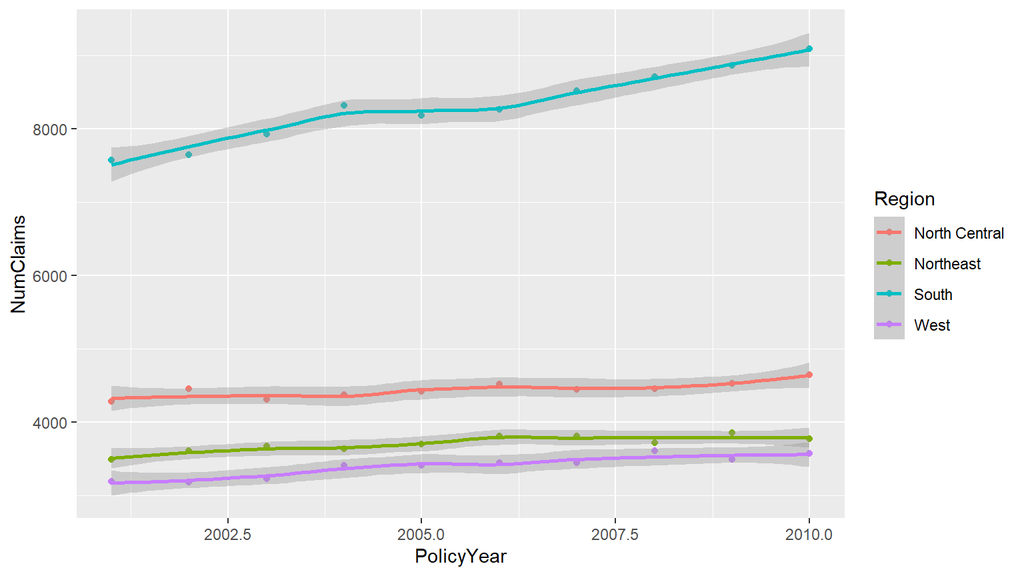

```r
p + geom_smooth()
```

## Linear smoother

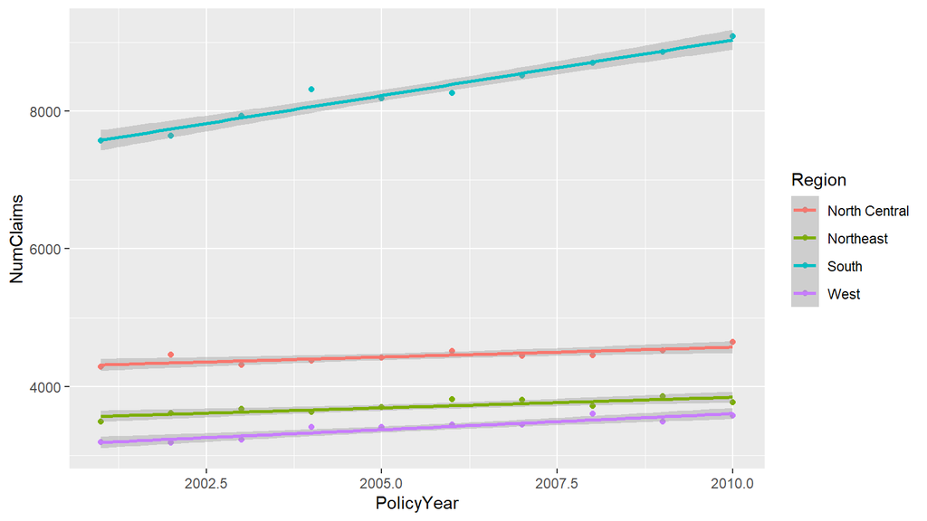

```r
p + geom_smooth(method = lm)
```

# Scales

## Scales

Scales control how things render on the plot. We must scale our numbers to the plotting device (typically a section of a computer screen.) We can also map things like color and axes to data values and control formatting.

## Scales

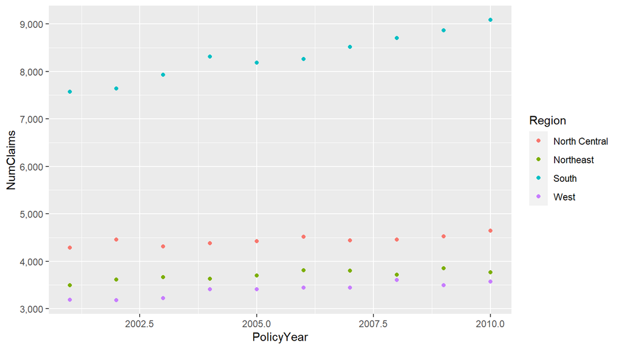

```r
p + scale_y_continuous(labels = scales::comma)
```

## Scales

The use of scales is a *very* detailed topic, particularly when we start talking about color. Your specific problem will likely require a bit of research and experimentation. StackOverflow.com is your friend.

## Non-data visual elements

Non-data elements are things like labels. Here’s a sample of a few:

- `xlab()`, `ylab()` -> `plt + ylab("This is my y label") + xlab("Here is an x label")`
- `ggtitle()` -> `plt + ggtitle("Title of my plot")`
- `labs()` -> `plt + labs(x = "x-axis title", title = "My title")`
- `theme_bw()`, `theme_minimal()` -> `plt + theme_bw()`
- The `theme()` function gives complete control over all non-data related visual elements
- Check out the `ggthemes` package

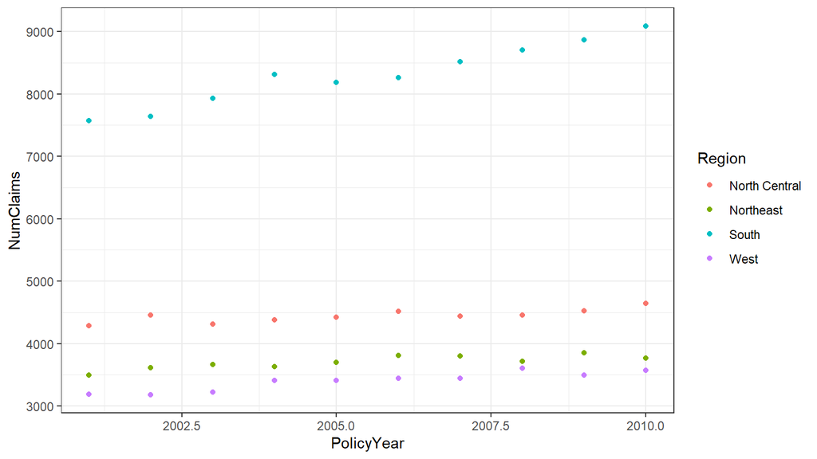

```r
p + theme_bw()
```

# One last example

```r
data("ppauto")

tbl_yasuda <- ppauto %>%
  filter(str_detect(Company, "Yasuda")) %>%
  group_by(AccidentYear) %>%
  arrange(Lag, .by_group = TRUE) %>%
  mutate(
    prior_cumulative_paid = lag(CumulativePaid)
    , incremental_paid = coalesce(
      CumulativePaid - prior_cumulative_paid
      , CumulativePaid
    )
  ) %>%
  ungroup()
```

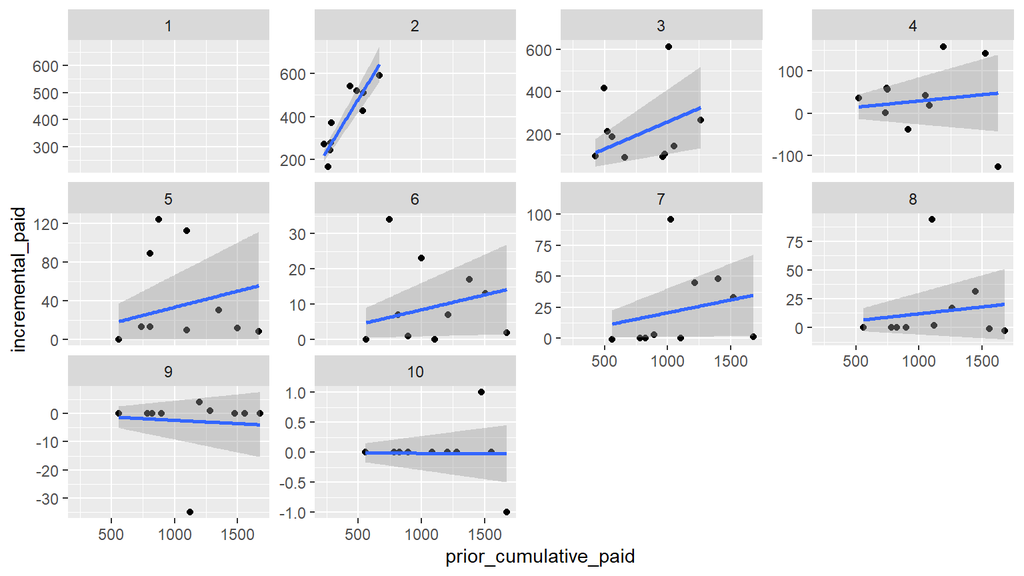

```r
tbl_yasuda %>%
  ggplot(aes(prior_cumulative_paid, incremental_paid)) +
  geom_point() +
  facet_wrap(~ Lag, scales = 'free_y') +
  geom_smooth(method = 'lm', formula = y ~ 0 + x)
```

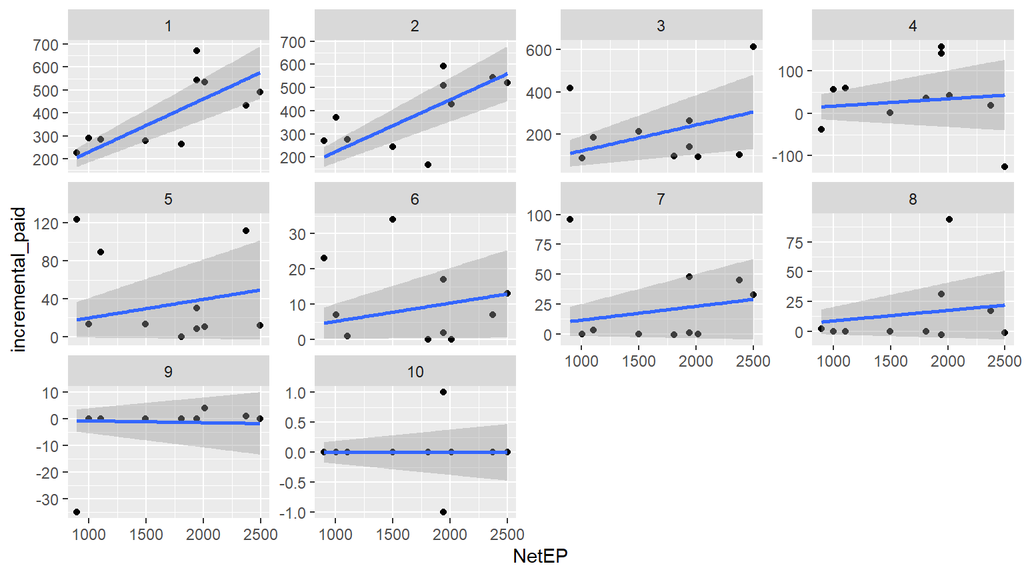

```r
tbl_yasuda %>%
  ggplot(aes(NetEP, incremental_paid)) +
  geom_point() +
  facet_wrap(~ Lag, scales = 'free_y') +
  geom_smooth(method = 'lm', formula = y ~ 0 + x)
```

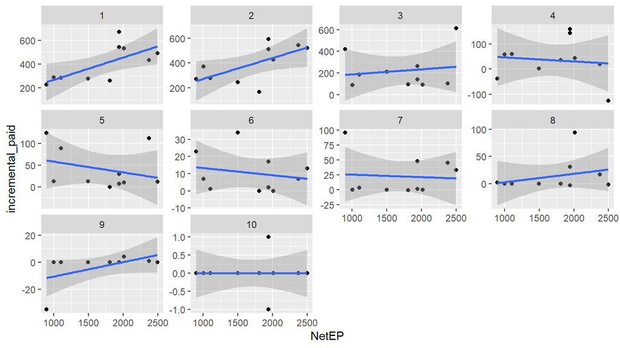

```r
tbl_yasuda %>%
  ggplot(aes(NetEP, incremental_paid)) +
  geom_point() +
  facet_wrap(~ Lag, scales = 'free_y') +
  geom_smooth(method = 'lm', formula = y ~ 1 + x)
```

# Summary

## Summary

- `ggplot2` may be difficult at first, but will repay your investment.
- Works very well with grouped data to color/facet points.
- Fine-tuning things like axis labels can be a headache, but will get easier. Yes, Excel makes it easier to add data labels and change colors. `ggplot2` makes it easier to work with data.

## Questions to ask when debugging

1. How am I mapping my data to an aesthetic?
2. How are these aesthetics handled by the geom that I’m using?
3. Have I used a factor rather than an integer?

## Reference

- http://www.rstudio.com/wp-content/uploads/2015/03/ggplot2-cheatsheet.pdf
- R Graphics Cookbook by Winston Chang
- http://vita.had.co.nz/papers/layered-grammar.html

## Your turn

1. Create a scatter plot for policy year and number of claims
2. Color each point based on region
3. Add a linear smoother. Which region is showing the greatest increase in claims?
4. Form the policy frequency by taking the ratio of claims to policies. Plot this.

Extra credit:

1. Use the state data to create a time series number of claims. Facet by region.